# STA243 Hw1 - Eric Kalosa-Kenyon

```r
library("ggplot2")          # fancy plotting
library("latex2exp")        # latex for plots
```

# 1

## 1.a

$p_n(x_1\dots x_n, \theta) = \prod_{i=1}^{n} p(x_i, \theta)$ where $p(x, \theta) = \frac{1}{\pi*(1+(x-\theta)^2)}$. Hence, $l_n(\theta) = \log{p_n(x_1\dots x_n, \theta)} = -n\log{\pi}-\sum_{i=1}^{n}{\log{1+(x_i-\theta)^2}}$

Further, $l_n^{'}(\theta) = \frac{\partial}{\partial \theta} l_n(\theta) = -\sum_{i=1}^{n} \frac{\partial}{\partial \theta} \log{1+(x_i-\theta)^2} = -2\sum_{i=1}^{n} \frac{\theta-x_i}{1+(x_i-\theta)^2}$.

Finally $l_n^{''}(\theta) = \frac{\partial^2}{\partial \theta^2} l_n(\theta) = \frac{\partial}{\partial \theta} l_n^{'}(\theta) = -2\sum_{i=1}^{n} \frac{1}{1+(x_i-\theta)^2} - (\theta-x_i)(1+(\theta-x_i)^2)^{-2}(2(\theta-x_i))$. Rewriting some terms, we find $l_n^{''}(\theta) = -2\sum_{i=1}^{n} \frac{1+(x_i-\theta)^2}{(1+(x_i-\theta)^2)^2} - \frac{-2(\theta-x_i)^2}{(1+(x_i-\theta)^2)^2}$ which simplifies to $l_n^{''}(\theta) = -2\sum_{i=1}^{n} \frac{1-(\theta-x_i)^2}{(1+(\theta-x_i)^2)^2}$ as desired.

## 1.b

The Fischer Information is calculated as follows: $I_n(\theta) = n*I(\theta)$. $I(\theta) = -E_\theta(l^{''}(\theta)) = -\int_{-\infty}^{\infty} p(x,\theta)*l^{''}(\theta) dx$. This simplifies to $\frac{2}{\pi} \int_{-\infty}^{\infty} \frac{1-(\theta-x)^2}{(1+(\theta-x)^2)^3} dx = \frac{2}{\pi} \frac{\pi}{4}$. Leveraging the first equality, we see that $I_n(\theta) = \frac{n}{2}$.

## 1.c

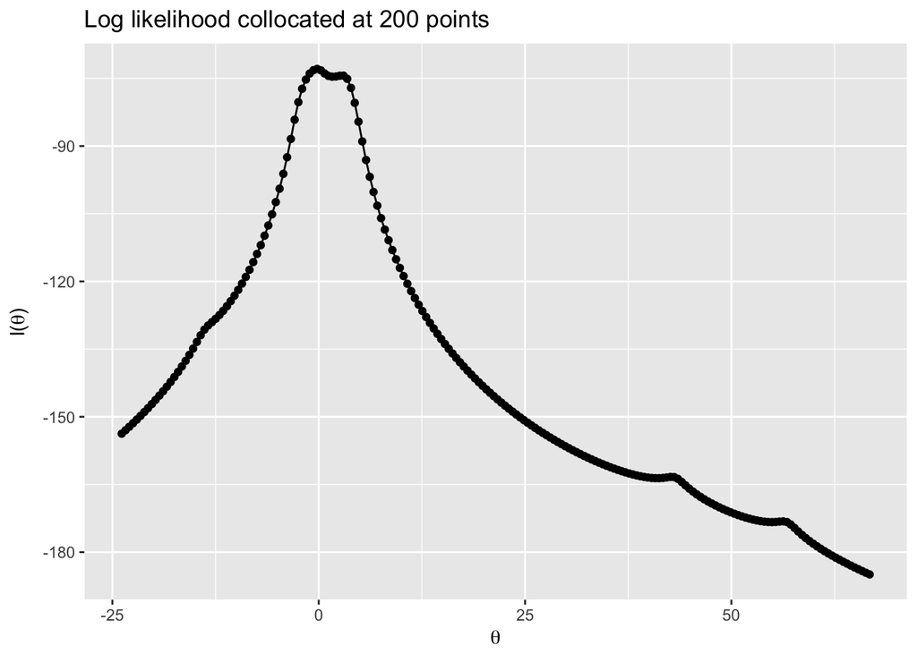

```r
p_1 = function(x, t){
    d = pi*(1+(x-t)^2)
    return(1/d)
}
l_1 = function(x, t){
    return(log(p_1(x,t)))
}
l_n = function(xs, t){
    r = 0
    for(x in xs){
        r = r + l_1(x, t)
    }
    return(r)
}

N = 200
raw = c(-13.87, -2.53, -2.44, -2.40, -1.75, -1.34, -1.05, -0.23, -0.07, 0.27,
        1.77, 2.76, 3.29, 3.47, 3.71, 3.80, 4.24, 4.53, 43.21, 56.75)
ts = seq(from=min(raw)-10, to=max(raw)+10, length=N)

df = data.frame(ts, l_n(xs=raw, t=ts))
names(df) = c("theta", "loglik")

g = qplot(df$theta, df$loglik) +
    geom_line() +
    ggtitle(paste("Log likelihood collocated at", N, "points")) +
    ylab(TeX("l($\\theta)")) + xlab(TeX("$\\theta"))
g
```

## 1.d

```r
xis = c(-11, -1, 0, 1.4, 4.1, 4.8, 7, 8, 38) # initial values for NR
eps = 0.001 # convergence criterion
delt = 0.0001 # increment parameter for derivatives

f_pdf = function(t){
    # Log likelihood given raw data as xs
    return(l_n(xs=raw, t=t))
}
fp = function(f, t, d){
    # first derivative aprox
    f0 = f(t-d/2)
    f1 = f(t+d/2)
    return((f1-f0)/d)
}
fpp = function(f, t, d){
    # second derivative aprox
    return(fp(fp(f, t, d), t, d))
}

nr_inc = function(f, x, d){
    # Increment x using the newton rhapson method
    return(x-f(x)/fp(f, x, d))
}

find_0s = function(f, x0, e, d, inc_fxn){
    # use NR to find a zero for the function
    x1 = inc_fxn(f, x0, d)
    while(abs(x1-x0)>e){
        # While we haven't converged, iterate the incrementing function (which
        # must have the signature [pdf, x, delta]) e.g. nr_inc
        x0 = x1
        x1 = inc_fxn(f, x0, d)

        if(abs(x1)==Inf){
            # If the algorithm diverges, return Inf
            return(Inf)
        }
    }

    # If we've converged (abs(x1-x0)<e) then return the convergent value
    return(x1)
}

f_find_0 = function(t){
    # This is the function we're finding the 0's of
    # In this case, it's the first derivative of the log likelihood (f_pdf)
    return(fp(f_pdf, t, delt))
}

xmax = c() # holds results of NR algorithm, Inf when divergent
for(xi in xis){
    xmax = c(xmax, find_0s(f_find_0, xi, eps, delt, nr_inc))
}
```

It is illustrative to examine the first derivative of the log likelihood function for insight on divergence conditions:

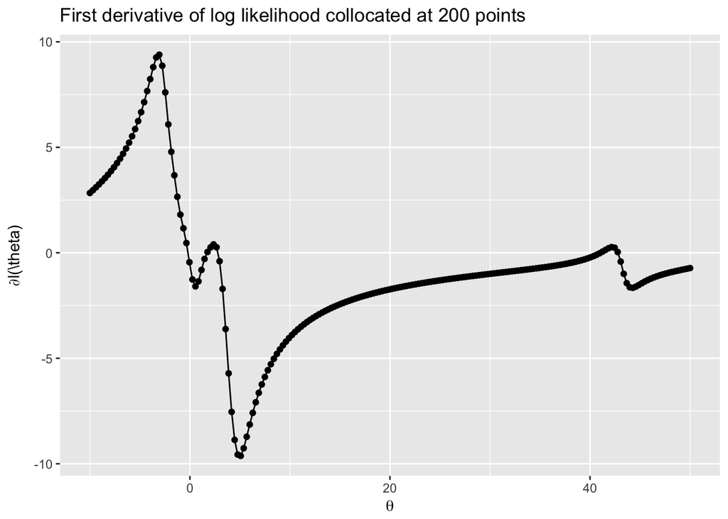

```r
N = 200
xss = seq(-10,50,length.out=N)
yss = f_find_0(xss)
df = data.frame(xss, yss)
g = qplot(df$xss, df$yss) +
    geom_line() +
    ggtitle(
        paste("First derivative of log likelihood collocated at",
              N,
              "points")) +
    ylab(TeX("$\\partial l($\\theta)")) +
    xlab(TeX("$\\theta"))
g
```

## 1.e

```r
fI = length(raw)/2  # I(\theta) = n/2 for the Cauchy dist.
fiscor_inc = function(f, x, d){
    # Increment x using the Fischer Scoring method
    return(x+f(x)/fI)
}
xmax = c() # holds results of FS algorithm, Inf when divergent
for(xi in xis){
    xmax = c(xmax, find_0s(f_find_0, xi, eps, delt, fiscor_inc))
}
```

# 2

In this problem we examine the behavior of MLE convergence using the Newton Rhapson method in the context of the pdf $f_\theta(x) = \frac{1-\cos(x-\theta)}{2\pi}$ where $0\le x \le 2\pi$ and $-\pi\le\theta\le\pi$.

# 2.a

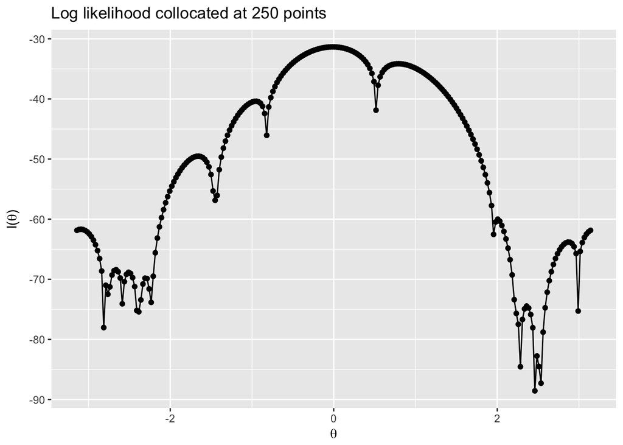

```r
raw = c(0.52, 1.96, 2.22, 2.28, 2.28, 2.46, 2.50, 2.53, 2.54, 2.99, 3.47, 3.53,
        3.70, 3.88, 3.91, 4.04, 4.06, 4.82, 4.85, 5.46)

p_1 = function(x, t){
    # Single dimensional pdf of x with parameter t

    # Domain checking
    if(x<0 || x>2*pi){
        return(0)
    }
    if(t< -pi || t>pi){
        return(0)
    }

    return((1-cos(x-t))/(2*pi))
}

l_n = function(xs, t){
    # multidimensional log likelihood for the above pdf
    r = 0
    for(x in xs){
        r = r + log(p_1(x, t))
    }
    return(r)
}

llik = function(t){
    # log likelihood above conditioned on observing the raw data above
    return(l_n(raw, t))
}

# Plot the loglikelihood
N = 250
ts = seq(from=-pi, to=pi, length=N)

df = data.frame(ts, llik(ts))
names(df) = c("theta", "loglik")

rm(g)
g = qplot(df$theta, df$loglik) +
    geom_line() +
    ggtitle(paste("Log likelihood collocated at", N, "points")) +
    ylab(TeX("l($\\theta)")) + xlab(TeX("$\\theta"))
g
```